# DataViz Makeover 1

# 4.1 Data Preparation

First of all, we download the data ‘outputFile.xlsx’ from the official website and check all the data we have. It contains three sheets, one is content, one is T1 (import) and another is T2 (export).

We can know that we have the import and export data of hundreds of countries in different time, the total number of countries of import and export are different (import 120 countries, export 92 countries), and the time period starts from Jan 1976, ends in Apr 2021.

1. Get the sheet contains only the data without other information.

Open the excel, copy the T1 sheet, which contains the import data, named the new sheet ‘import’ and delete the rows contains other information before and after the data.

before:

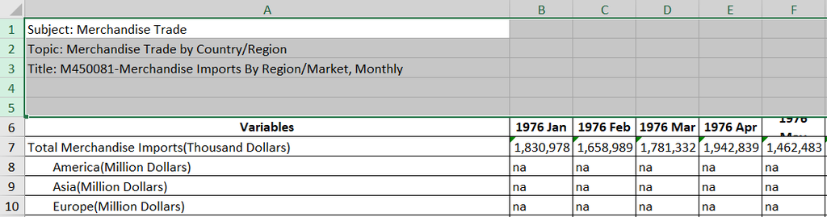

after:

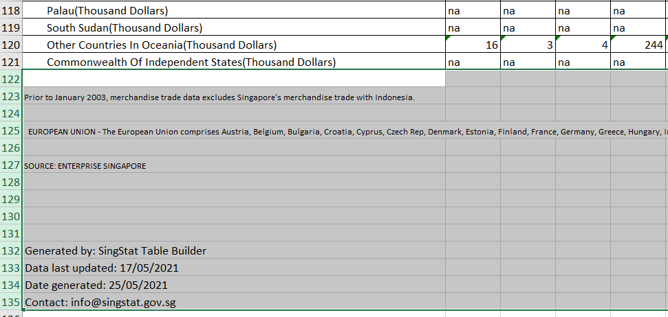

Do the same steps for export data (T2) and get a new sheet ‘export’.

2. Get the statistic of import and export compare with the performance last year, only for 2020.

Make copies of import and export sheet, named ‘Im_inter’ and ‘Ex_inter’. In the ‘Im_inter’ sheet, select the cells of first row and add a filter. In the ‘variables’ column select the specific six countries.

Copy the value from Jan 2019 to Dec 2020 and paste below.

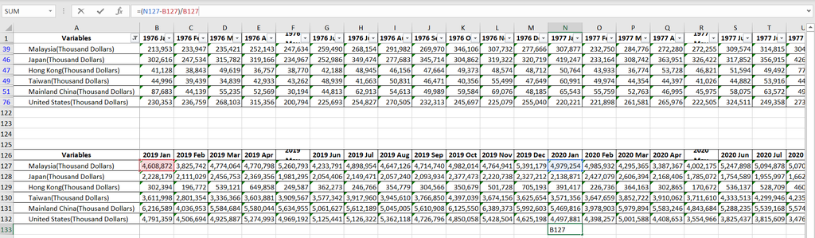

In the cell below 2020 Jan, type in the formula ‘the year-on-year ratio = (the import value in a specific month in 2020 - the import value of the month in 2019) / the import value of the month in 2019’ and drag down and right to get all the percentage of the six countries in 2020.

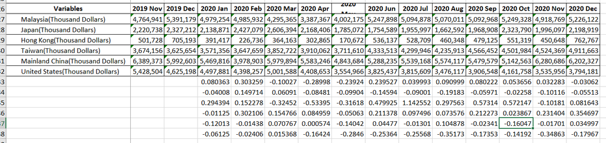

We copy all the percentage statistics and prepare a new sheet ‘Im_yoyr’ for further tableau exploration.

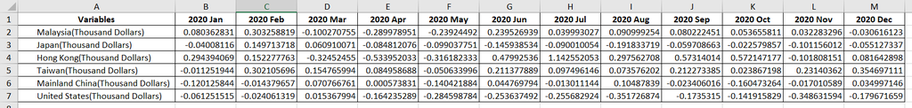

Then do the same steps for export part and get a new sheet ‘Ex_yoyr’.

## 4.2 Data Visualization

Now we open the tableau and start to create our visualization.

1. Set the data source.

We import the ‘outputFile.xlsx’ and drag the ‘import’ to the up right window. Select the columns from ‘1976 Jan’ to ‘Apr 2021’ by click the first column, press ‘shift’ and click the last column, right click and select ‘pivot’.

[figure not shown]

Then change the name of the three columns to ‘country’, ‘period’ and ‘merchandise import’. Click the ‘abc’ icon above ‘period’ column and change the data type to date, change the type of ‘merchandise import’ from ‘abc’ to ‘number(decimal)’ using the same way. Now the table looks like this.

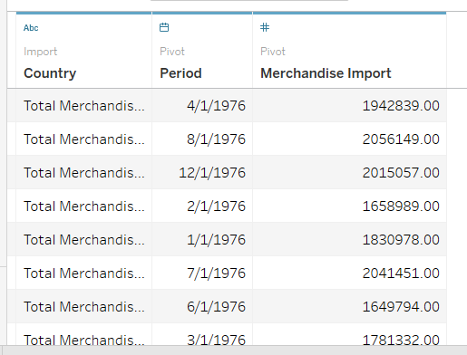

Then drag the export to the window and make the same changes. Also, set the relation ship between the import and export. It matches when country in import equals country Ex in export and period equals period Ex, the cardinality is one to one.

[figure not shown]

Drag the ‘Im_yoyr’ to the window link to import. select all the columns exclude variables and pivot the table. Do the same changes to column name, column type and the relationship as figure below.

[figure not shown]

Do the same steps for ‘Ex_yoyr’ and the result should looks like the figure below.

[figure not shown]

2. Make a new visualization of the import and export data of the six countries from 2019 to 2020.

First we check the ‘Tables’ and change the ‘merchandise import’ and ‘merchandise export’ from discrete to continuous.

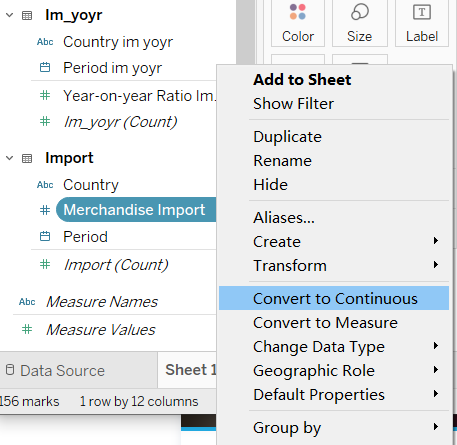

And Drag ‘merchandise import’ below.

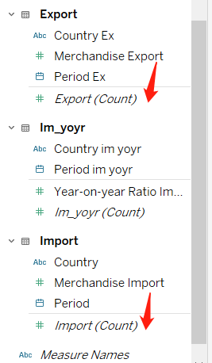

First we drag the ‘Country’ of ‘Import’ to ‘Filters’ and check the six countries (Hong Kong, Japan, Mainland China, Malaysia, Taiwan, US), click OK.

[figure not shown]

Then we drag ‘Periof’ of ‘Import’ to ‘Filters’ and select ‘#year’ click next and check only 2019, 2020.

[figure not shown]

We drag ‘Country’ and ‘Period’ from ‘Import’ to columns, click the plus icon to get the ‘month’ of ‘period’, and change the ‘month’ from discrete to continuous. Then we drag ‘Quarter’ and ‘year’ out.

[figure not shown]

We drag ‘merchandise import’ from ‘import’ to rows. Then drag ‘merchandise export’ from ‘export’ to the Y axis.

[figure not shown]

Click the triangle above ‘Tables’ and select ‘create calculate field’, set the name to ‘Balance of Trade’ and the formula is ‘Balance of Trade = value of Exports - value of Imports’.

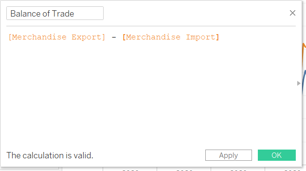

Drag the ‘Balance of Trade’ from ‘Measure Names’ to the Y axis and change the color of the three lines.

[figure not shown]

Finally, we do following steps to modify the graph.

Right click columns label area and select hide field labels for columns.

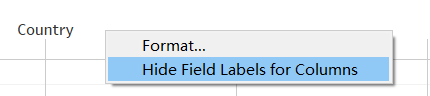

Right click Y axis and change the name of Y axis to ‘Value of Import/Export/Balance of Trade (Thousand Dollars)’.

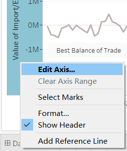

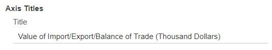

Right click the country name, select edit the X alias for all six countries, delete the space before country name and the note after country name.

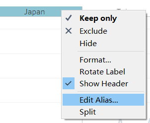

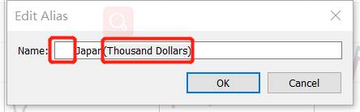

Then right click title area and edit the title and subtitle.

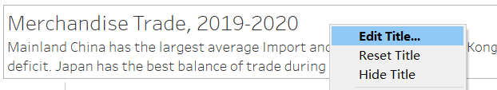

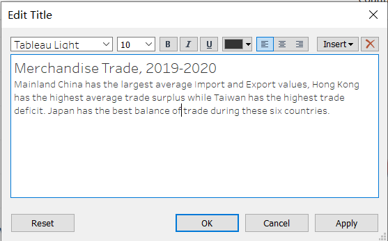

Right click the white space in the graph, hang on annotate and select area to add the annotation to the graph.

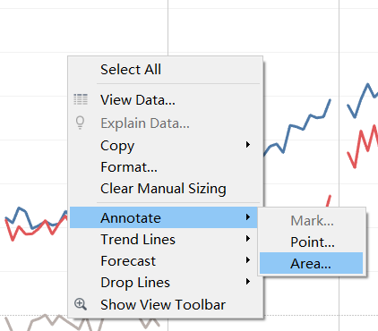

Right click the legend, select edit title and delete it in the new window. Then right click ‘Merchandise Import’ and select edit alias to delete ‘Merchandise’ and remain ‘Import’. Do the same for ‘Export’.

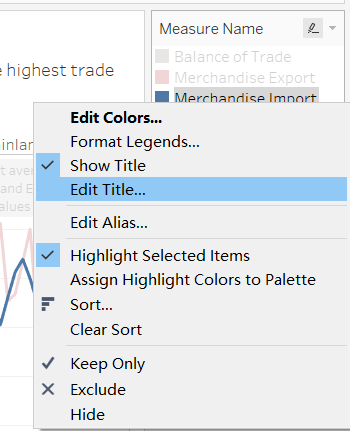

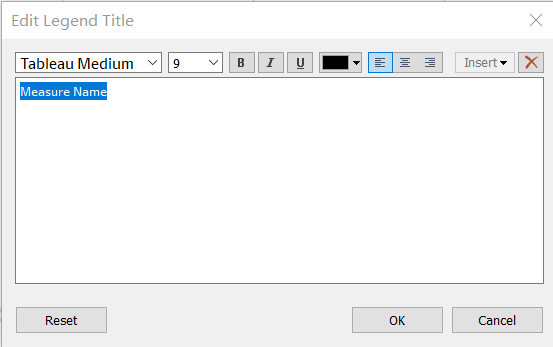

The final ‘Merchandise Trade’ is as follow.

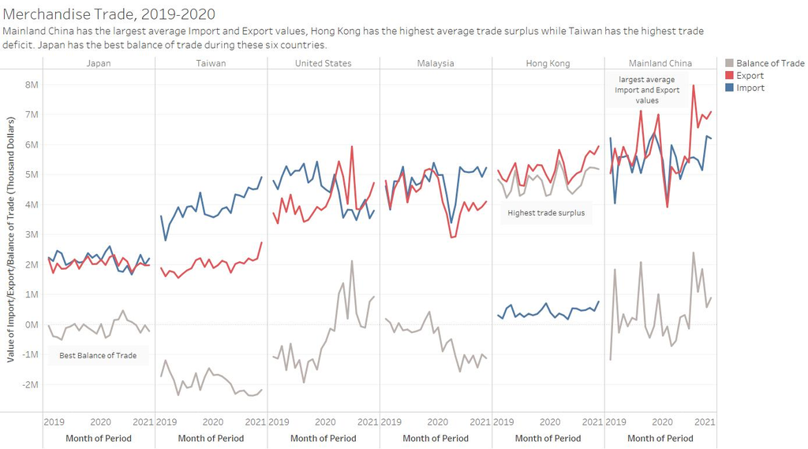

3. Create a line chart to show the year-on-year ratio of both import and export values for the six countries.

We drag the ‘Period im yoyr’ from ‘Im_yoyr’ to columns, change the level from year to month, and change it from discrete to continuous, remove ‘quarter’ and ‘year’.

Drag the ‘Year-on-year Ratio Import’ and ‘Year-on-year Ratio Export’ from ‘Im_yoyr’ and ‘Ex_yoyr’ to rows.